# Project 1: Analyzing the No Show Appointments Dataset

- Introduction
- Data Wrangling
- Exploratory Data Analysis
- Conclusions

## Introduction

This document will report on the No Show Appointments dataset, which includes 110527 records and 14 features of appointments from Brazil.

**Main Question:** What features would be required to predict the likelihood of a patient showing up to their appointment?

*Further Exploratory Questions:*

1. Would a patient's enrollment in the social welfare program [Bolsa Família](https://en.wikipedia.org/wiki/Bolsa_Fam%C3%ADlia) affect their likelihood to show up
2. How do the age groups and genders compare in likelihood to show up
3. For which medical conditions are patients more commited to showing up
4. Do notifications by SMS help the patient attend their appointments

```python
import pandas as pd
import numpy as np
import matplotlib.pyplot as plt
import seaborn as sns
from datetime import datetime

sns.set_style("whitegrid", rc={'axes.facecolor':'whitesmoke', 'figure.facecolor':'whitesmoke'})

%matplotlib inline
```

## Data Wrangling

### General Properties

```python
df = pd.read_csv("noshowappointments-kagglev2-may-2016.csv")
```

```python
df.head()
```

|  | PatientId | AppointmentID | Gender | ScheduledDay | AppointmentDay | Age | Neighbourhood | Scholarship | Hipertension | Diabetes | Alcoholism | Handcap | SMS_received | No-show |
| --- | --- | --- | --- | --- | --- | --- | --- | --- | --- | --- | --- | --- | --- | --- |
| 0 | 2.987250e+13 | 5642903 | F | 2016-04-29T18:38:08Z | 2016-04-29T00:00:00Z | 62 | JARDIM DA PENHA | 0 | 1 | 0 | 0 | 0 | 0 | No |
| 1 | 5.589978e+14 | 5642503 | M | 2016-04-29T16:08:27Z | 2016-04-29T00:00:00Z | 56 | JARDIM DA PENHA | 0 | 0 | 0 | 0 | 0 | 0 | No |
| 2 | 4.262962e+12 | 5642549 | F | 2016-04-29T16:19:04Z | 2016-04-29T00:00:00Z | 62 | MATA DA PRAIA | 0 | 0 | 0 | 0 | 0 | 0 | No |
| 3 | 8.679512e+11 | 5642828 | F | 2016-04-29T17:29:31Z | 2016-04-29T00:00:00Z | 8 | PONTAL DE CAMBURI | 0 | 0 | 0 | 0 | 0 | 0 | No |
| 4 | 8.841186e+12 | 5642494 | F | 2016-04-29T16:07:23Z | 2016-04-29T00:00:00Z | 56 | JARDIM DA PENHA | 0 | 1 | 1 | 0 | 0 | 0 | No |

```python
df.info()
```

```
<class 'pandas.core.frame.DataFrame'>
RangeIndex: 110527 entries, 0 to 110526
Data columns (total 14 columns):
 #   Column          Non-Null Count   Dtype
---  ------          --------------   -----
 0   PatientId       110527 non-null  float64
 1   AppointmentID   110527 non-null  int64
 2   Gender          110527 non-null  object
 3   ScheduledDay    110527 non-null  object
 4   AppointmentDay  110527 non-null  object
 5   Age             110527 non-null  int64
 6   Neighbourhood   110527 non-null  object
 7   Scholarship     110527 non-null  int64
 8   Hipertension    110527 non-null  int64
 9   Diabetes        110527 non-null  int64
 10  Alcoholism      110527 non-null  int64
 11  Handcap         110527 non-null  int64
 12  SMS_received    110527 non-null  int64
 13  No-show         110527 non-null  object
dtypes: float64(1), int64(8), object(5)
memory usage: 11.8+ MB
```

```python
df.describe()
```

|  | PatientId | AppointmentID | Age | Scholarship | Hipertension | Diabetes | Alcoholism | Handcap | SMS_received |
| --- | --- | --- | --- | --- | --- | --- | --- | --- | --- |
| count | 1.105270e+05 | 1.105270e+05 | 110527.000000 | 110527.000000 | 110527.000000 | 110527.000000 | 110527.000000 | 110527.000000 | 110527.000000 |
| mean | 1.474963e+14 | 5.675305e+06 | 37.088874 | 0.098266 | 0.197246 | 0.071865 | 0.030400 | 0.022248 | 0.321026 |
| std | 2.560949e+14 | 7.129575e+04 | 23.110205 | 0.297675 | 0.397921 | 0.258265 | 0.171686 | 0.161543 | 0.466873 |
| min | 3.921784e+04 | 5.030230e+06 | -1.000000 | 0.000000 | 0.000000 | 0.000000 | 0.000000 | 0.000000 | 0.000000 |
| 25% | 4.172614e+12 | 5.640286e+06 | 18.000000 | 0.000000 | 0.000000 | 0.000000 | 0.000000 | 0.000000 | 0.000000 |
| 50% | 3.173184e+13 | 5.680573e+06 | 37.000000 | 0.000000 | 0.000000 | 0.000000 | 0.000000 | 0.000000 | 0.000000 |
| 75% | 9.439172e+13 | 5.725524e+06 | 55.000000 | 0.000000 | 0.000000 | 0.000000 | 0.000000 | 0.000000 | 1.000000 |
| max | 9.999816e+14 | 5.790484e+06 | 115.000000 | 1.000000 | 1.000000 | 1.000000 | 1.000000 | 4.000000 | 1.000000 |

**Checking for duplicates & null values**

```python
sum(df.duplicated())
```

```
0
```

> No duplicate values

```python
df.isnull().values.any()
```

```
False
```

> No null values

**Checking for possible issues in string type features**

```python
df["Gender"].unique()
```

```
array(['F', 'M'], dtype=object)
```

> Values are normal

```python
df["Neighbourhood"].unique()
```

```
array(['JARDIM DA PENHA', 'MATA DA PRAIA', 'PONTAL DE CAMBURI',
       'REPÚBLICA', 'GOIABEIRAS', 'ANDORINHAS', 'CONQUISTA',
       'NOVA PALESTINA', 'DA PENHA', 'TABUAZEIRO', 'BENTO FERREIRA',
       'SÃO PEDRO', 'SANTA MARTHA', 'SÃO CRISTÓVÃO', 'MARUÍPE',
       'GRANDE VITÓRIA', 'SÃO BENEDITO', 'ILHA DAS CAIEIRAS',
       'SANTO ANDRÉ', 'SOLON BORGES', 'BONFIM', 'JARDIM CAMBURI',
       'MARIA ORTIZ', 'JABOUR', 'ANTÔNIO HONÓRIO', 'RESISTÊNCIA',
       'ILHA DE SANTA MARIA', 'JUCUTUQUARA', 'MONTE BELO',
       'MÁRIO CYPRESTE', 'SANTO ANTÔNIO', 'BELA VISTA', 'PRAIA DO SUÁ',
       'SANTA HELENA', 'ITARARÉ', 'INHANGUETÁ', 'UNIVERSITÁRIO',
       'SÃO JOSÉ', 'REDENÇÃO', 'SANTA CLARA', 'CENTRO', 'PARQUE MOSCOSO',
       'DO MOSCOSO', 'SANTOS DUMONT', 'CARATOÍRA', 'ARIOVALDO FAVALESSA',
       'ILHA DO FRADE', 'GURIGICA', 'JOANA D´ARC', 'CONSOLAÇÃO',
       'PRAIA DO CANTO', 'BOA VISTA', 'MORADA DE CAMBURI', 'SANTA LUÍZA',
       'SANTA LÚCIA', 'BARRO VERMELHO', 'ESTRELINHA', 'FORTE SÃO JOÃO',
       'FONTE GRANDE', 'ENSEADA DO SUÁ', 'SANTOS REIS', 'PIEDADE',
       'JESUS DE NAZARETH', 'SANTA TEREZA', 'CRUZAMENTO',
       'ILHA DO PRÍNCIPE', 'ROMÃO', 'COMDUSA', 'SANTA CECÍLIA',
       'VILA RUBIM', 'DE LOURDES', 'DO QUADRO', 'DO CABRAL', 'HORTO',
       'SEGURANÇA DO LAR', 'ILHA DO BOI', 'FRADINHOS', 'NAZARETH',
       'AEROPORTO', 'ILHAS OCEÂNICAS DE TRINDADE', 'PARQUE INDUSTRIAL'],
      dtype=object)
```

> Values are normal

```python
df["AppointmentDay"].unique()
```

```
array(['2016-04-29T00:00:00Z', '2016-05-03T00:00:00Z',
       '2016-05-10T00:00:00Z', '2016-05-17T00:00:00Z',
       '2016-05-24T00:00:00Z', '2016-05-31T00:00:00Z',
       '2016-05-02T00:00:00Z', '2016-05-30T00:00:00Z',
       '2016-05-16T00:00:00Z', '2016-05-04T00:00:00Z',
       '2016-05-19T00:00:00Z', '2016-05-12T00:00:00Z',
       '2016-05-06T00:00:00Z', '2016-05-20T00:00:00Z',
       '2016-05-05T00:00:00Z', '2016-05-13T00:00:00Z',
       '2016-05-09T00:00:00Z', '2016-05-25T00:00:00Z',
       '2016-05-11T00:00:00Z', '2016-05-18T00:00:00Z',
       '2016-05-14T00:00:00Z', '2016-06-02T00:00:00Z',
       '2016-06-03T00:00:00Z', '2016-06-06T00:00:00Z',
       '2016-06-07T00:00:00Z', '2016-06-01T00:00:00Z',
       '2016-06-08T00:00:00Z'], dtype=object)
```

> Values are normal

**Miscellaneous**

```python
df["PatientId"].nunique()
```

```
62299
```

> Patients can have had multiple appointments (shouldn't affect analysis)

```python
df["AppointmentID"].is_unique
```

```
True
```

> No duplicate IDs. Values are normal

**Items of note**:

- Features *PatientId*, *AppointmentID*, *AppointmentDay* & *ScheduledDay* will not be used for analysis.
- *Age* has -1 value which is impossible and will be dropped.
- *AppointmentDay* is a string, which would make analysis inefficient. There are no time values, so the format will be changed to display date only.
- *Scholarship*, *Hipertension*, *Diabetes*, *Alcoholism*, & *SMS_received* will be converted to boolean.
- *No-show* can be confusing. It will be renamed to *Showed_Up* and values will be inverted for readability and clarity. Its datatype will be converted to boolean.

### Data Cleaning

```python
df_clean = df.copy()
```

**Dropping unwanted features**

```python
df_clean.drop(columns=["PatientId", "AppointmentID", "ScheduledDay", "AppointmentDay"], inplace=True)
```

```python
df_clean.head()
```

|  | Gender | Age | Neighbourhood | Scholarship | Hipertension | Diabetes | Alcoholism | Handcap | SMS_received | No-show |
| --- | --- | --- | --- | --- | --- | --- | --- | --- | --- | --- |
| 0 | F | 62 | JARDIM DA PENHA | 0 | 1 | 0 | 0 | 0 | 0 | No |
| 1 | M | 56 | JARDIM DA PENHA | 0 | 0 | 0 | 0 | 0 | 0 | No |
| 2 | F | 62 | MATA DA PRAIA | 0 | 0 | 0 | 0 | 0 | 0 | No |
| 3 | F | 8 | PONTAL DE CAMBURI | 0 | 0 | 0 | 0 | 0 | 0 | No |
| 4 | F | 56 | JARDIM DA PENHA | 0 | 1 | 1 | 0 | 0 | 0 | No |

**Dropping records with *Age* of -1**

```python
df_clean = df_clean[df_clean["Age"] != -1]
(df_clean["Age"] == -1).sum()
```

```
0
```

**Changing datatype to boolean**

```python
for i in ["Scholarship", "Hipertension", "Diabetes", "Alcoholism", "SMS_received"]:
    df_clean[i] = df_clean[i].astype(bool)
```

**Modifying *No-show***

```python
df_clean = df_clean.rename(columns={"No-show": "Showed_up"})
df_clean.loc[df_clean["Showed_up"] == "Yes", ["Showed_up"]] = 0
df_clean.loc[df_clean["Showed_up"] == "No", ["Showed_up"]] = 1
df_clean["Showed_up"] = pd.to_numeric(df_clean["Showed_up"]).astype(bool)
```

```python
df_clean["Showed_up"].unique()
```

```
array([ True, False])
```

**Final cleaned dataframe**

```python
df_clean.head()
```

|  | Gender | Age | Neighbourhood | Scholarship | Hipertension | Diabetes | Alcoholism | Handcap | SMS_received | Showed_up |
| --- | --- | --- | --- | --- | --- | --- | --- | --- | --- | --- |
| 0 | F | 62 | JARDIM DA PENHA | False | True | False | False | 0 | False | True |
| 1 | M | 56 | JARDIM DA PENHA | False | False | False | False | 0 | False | True |
| 2 | F | 62 | MATA DA PRAIA | False | False | False | False | 0 | False | True |
| 3 | F | 8 | PONTAL DE CAMBURI | False | False | False | False | 0 | False | True |
| 4 | F | 56 | JARDIM DA PENHA | False | True | True | False | 0 | False | True |

```python
df_clean.info()
```

```
<class 'pandas.core.frame.DataFrame'>
Int64Index: 110526 entries, 0 to 110526
Data columns (total 10 columns):
 #   Column         Non-Null Count   Dtype
---  ------         --------------   -----
 0   Gender         110526 non-null  object
 1   Age            110526 non-null  int64
 2   Neighbourhood  110526 non-null  object
 3   Scholarship    110526 non-null  bool
 4   Hipertension   110526 non-null  bool
 5   Diabetes       110526 non-null  bool
 6   Alcoholism     110526 non-null  bool
 7   Handcap        110526 non-null  int64
 8   SMS_received   110526 non-null  bool
 9   Showed_up      110526 non-null  bool
dtypes: bool(6), int64(2), object(2)
memory usage: 4.8+ MB
```

## Exploratory Data Analysis

#### Miscellaneous Functions

Bar plot annotation code from [*Data Viz with Python and R*](https://datavizpyr.com/how-to-annotate-bars-in-barplot-with-matplotlib-in-python/)

```python
def annotate_barplot(_ax, _format):
    for p in _ax.patches:
        _ax.annotate(format(p.get_height(), _format),
                     (p.get_x() + p.get_width() / 2., p.get_height()),
                     ha = 'center', va = 'center',
                     xytext = (0, 9),textcoords = 'offset points')
```

### Preliminary Visualization

#### Correlation Matrix

from [*Seaborn documentation*](https://en.wikipedia.org/wiki/Bolsa_Fam%C3%ADlia)

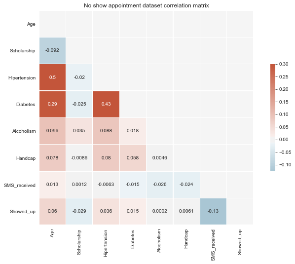

```python
# correlation matrix
correlationmatrix = df_clean.corr()

# Mask to hide upper triangle
mask = np.triu(np.ones_like(correlationmatrix, dtype=bool))

f, ax = plt.subplots(figsize=(12, 8))
cmap = sns.diverging_palette(230, 20, as_cmap=True)
ax.set_title("No show appointment dataset correlation matrix")
sns.heatmap(correlationmatrix, mask=mask, cmap=cmap, vmax=.3, center=0, annot=True, square=True, linewidths=.5, cbar_kws={"shrink": .5});
```

**Items of Note:**

- For *Showed_up* feature, there doesn't seem to be any strong correlation with any other feature.
- *SMS_received* seems to be with the strongest negative correlation (-0.13) for likelihood to show up
- *Age* seems to be with the strongest positive correlation (0.06) for likelihood to show up
- Other features have correlations that will most likely be too weak to show up substantially in visualization, but a predictive machine learning model would be able to make use of them

#### Demographics

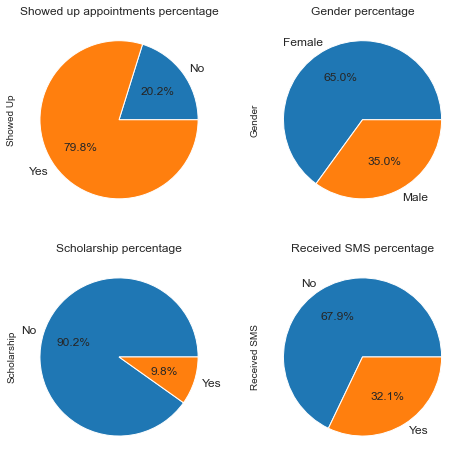

```python
fig, axs = plt.subplots(2,2, figsize = (8,8))

df_clean.groupby("Showed_up").size().plot.pie(autopct="%.1f%%", textprops={"fontsize": 12}, label = "Showed Up", labels = ["No", "Yes"], ax = axs[0,0])
axs[0,0].set_title("Showed up appointments percentage")

df_clean.groupby("Gender").size().plot.pie(autopct="%.1f%%", textprops={"fontsize": 12}, label = "Gender", labels = ["Female", "Male"], ax = axs[0,1])
axs[0,1].set_title("Gender percentage")

df_clean.groupby("Scholarship").size().plot.pie(autopct="%.1f%%", textprops={"fontsize": 12}, label = "Scholarship", labels = ["No", "Yes"], ax = axs[1,0])
axs[1,0].set_title("Scholarship percentage")

df_clean.groupby("SMS_received").size().plot.pie(autopct="%.1f%%", textprops={"fontsize": 12}, label = "Received SMS", labels = ["No", "Yes"], ax = axs[1,1]);
axs[1,1].set_title("Received SMS percentage")
```

**Items of Note:**

- For a significant portion of appointments, the patients did not show up (20.2%)
- Most of the appointments were for female patients (65%)
- Very few appointments were for patients that are enrolled in Bolsa Família (9.8%)
- About a third of the appointments had SMS messages sent to their respective patients (32.1%)

#### Conditions

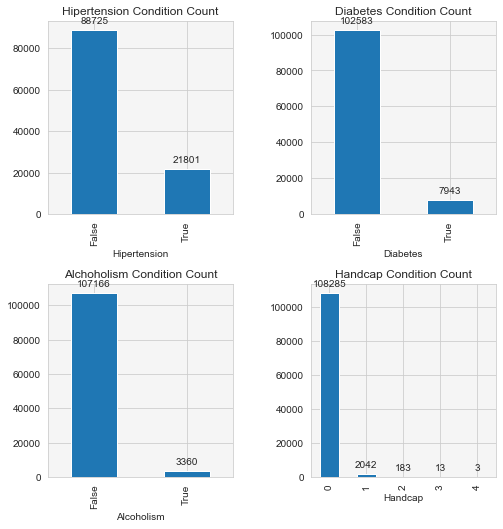

```python
fig, axs = plt.subplots(2,2, figsize = (8,8))
fig.tight_layout(pad=5.0)

df_clean.groupby("Hipertension").size().plot(kind = "bar", ax = axs[0,0])
axs[0,0].set_title("Hipertension Condition Count")

df_clean.groupby("Diabetes").size().plot(kind = "bar", ax = axs[0,1])
axs[0,1].set_title("Diabetes Condition Count")

df_clean.groupby("Alcoholism").size().plot(kind = "bar", ax = axs[1,0])
axs[1,0].set_title("Alchoholism Condition Count")

df_clean.groupby("Handcap").size().plot(kind = "bar", ax = axs[1,1]);
axs[1,1].set_title("Handcap Condition Count")

for ax in [axs[0,0], axs[0,1], axs[1,0], axs[1,1]]:
    annotate_barplot(ax, '.0f')
```

```python
# Percentage of appointments for patients without any of the medical conditions
df_clean.loc[(df_clean["Hipertension"] == False) & (df_clean["Diabetes"] == False) & (df_clean["Alcoholism"] == False) & (df_clean["Handcap"] == 0)].shape[0]/df_clean.shape[0]
```

```
0.7610336029531513
```

**Items of Note:**

- For each medical condition, most appointments were for patients unaffected by them.
- 76.1% of appointments were for patients unaffected by any of the conditions

### 1. Social welfare enrollment & likelihood to show up

```python
# Only keeping required features for the copy
df_q1 = df_clean.filter(["Scholarship", "Showed_up"])
```

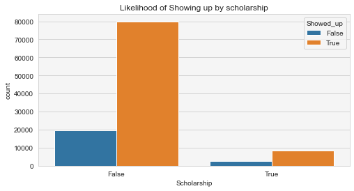

```python
plt.figure(figsize=(8,4))
ax = sns.countplot(x=df_q1["Scholarship"] , hue = df_q1["Showed_up"])
ax.set_title("Likelihood of Showing up by scholarship")
plt.show()
```

Difficult to conclude anything from a count plot as the scale for those with a scholarship is too small in comparison.  
To illustrate it better, the percentage of showed up appointments will be used instead

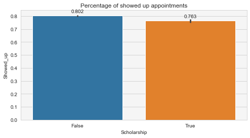

```python
plt.figure(figsize=(8,4))
ax = sns.barplot(x="Scholarship", y = "Showed_up", data = df_q1)

for p in ax.patches:
    ax.annotate(format(p.get_height(), '.3f'),
                   (p.get_x() + p.get_width() / 2., p.get_height()),
                   ha = 'center', va = 'center',
                   xytext = (0, 9),
                   textcoords = 'offset points')

ax.set_title("Percentage of showed up appointments");
```

**Items of Note:**

- The initial barplot was not illustrative enough, given that only 10% of appointments were for scholarship holders
- Appointmetns for patients enrolled in the social welfare program were 3.9% more likely to have the patient not show up.
- This confirms the very weak negative correlation found through the heatmap (-0.029)
- The *Scholarship* feature could be used to indicate the likelihood of a patient to show up to their appointment

### 2. Age/Gender & likelihood to show up

```python
# Only keeping required features for the copy
df_q2 = df_clean.filter(["Age", "Gender", "Showed_up"])

#Binning for better visualization
df_q2['Age_group'] = pd.cut(x=df_q2['Age'],
                            bins=12,
                            labels=["00-05", "05-15", "15-25", "25-35", "35-45", "45-55", "55-65", "65-75", "75-85", "85-95", "95-105", "105-115"])

df_q2.sample(n=5, random_state=1)
```

|  | Age | Gender | Showed_up | Age_group |
| --- | --- | --- | --- | --- |
| 55059 | 65 | F | True | 55-65 |
| 51067 | 9 | M | True | 00-05 |
| 32977 | 3 | M | True | 00-05 |
| 62131 | 18 | F | False | 05-15 |
| 29906 | 65 | F | True | 55-65 |

```python
df_q2.isnull().values.any()
```

```
False
```

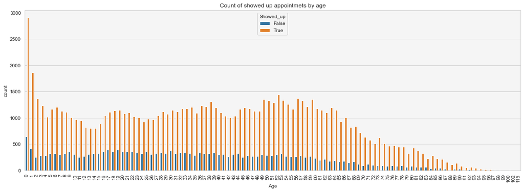

```python
plt.figure(figsize=(18,6))
plt.xticks(rotation=90)
ax = sns.countplot(x=df_q2["Age"], hue=df_q2["Showed_up"]);
ax.set_title("Count of showed up appointmets by age");
```

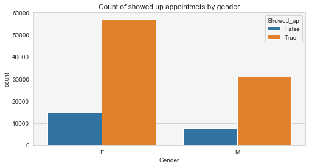

```python
plt.figure(figsize=(8,4))
ax = sns.countplot(x=df_q2["Gender"], hue=df_q2["Showed_up"]);
ax.set_title("Count of showed up appointmets by gender");
```

Similar to the previous question, a bar graph does not show any interesting details. The percentages will be used instead.

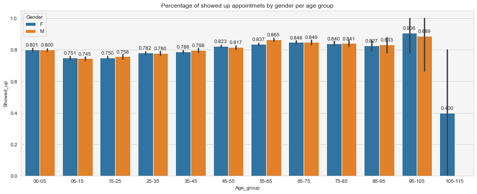

```python
plt.figure(figsize=(16,6))
ax = sns.barplot(x="Age_group", y="Showed_up", hue='Gender', data=df_q2);
annotate_barplot(ax, '.3f')
ax.set_title("Percentage of showed up appointmets by gender per age group");
```

```python
df_q2[df_q2["Age_group"] == '105-115']
```

|  | Age | Gender | Showed_up | Age_group |
| --- | --- | --- | --- | --- |
| 63912 | 115 | F | False | 105-115 |
| 63915 | 115 | F | False | 105-115 |
| 68127 | 115 | F | False | 105-115 |
| 76284 | 115 | F | True | 105-115 |
| 97666 | 115 | F | True | 105-115 |

### 3. Patient's medical conditions & likelihood to show up

```python
# Only keeping required features for the copy
df_q3 = df_clean.filter(["Hipertension", "Diabetes", "Alcoholism", "Handcap", "Showed_up"])
df_q3.head()
```

|  | Hipertension | Diabetes | Alcoholism | Handcap | Showed_up |
| --- | --- | --- | --- | --- | --- |
| 0 | True | False | False | 0 | True |
| 1 | False | False | False | 0 | True |
| 2 | False | False | False | 0 | True |
| 3 | False | False | False | 0 | True |
| 4 | True | True | False | 0 | True |

From the Preliminary Visualization, we could see that most of the appointments were for patients without the medical condition features.  
Due to this, the percentages of appointments where patients showed up will be used, instead of a total count.

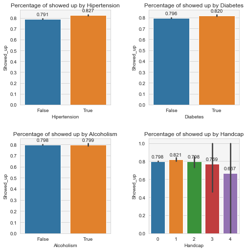

```python
fig, axs = plt.subplots(2,2, figsize = (8,8))
fig.tight_layout(pad=5.0)

sns.barplot(x = "Hipertension", y = "Showed_up", data = df_q3, ax = axs[0,0])
axs[0,0].set_title("Percentage of showed up by Hipertension")

sns.barplot(x = "Diabetes", y = "Showed_up", data = df_q3, ax = axs[0,1])
axs[0,1].set_title("Percentage of showed up by Diabetes")

sns.barplot(x = "Alcoholism", y = "Showed_up", data = df_q3, ax = axs[1,0])
axs[1,0].set_title("Percentage of showed up by Alcoholism")

sns.barplot(x = "Handcap", y = "Showed_up", data = df_q3, ax = axs[1,1])
axs[1,1].set_title("Percentage of showed up by Handcap")

for ax in [axs[0,0], axs[0,1], axs[1,0], axs[1,1]]:
    annotate_barplot(ax, '.3f')
```

**Items of Note:**

- Appointments for patients with *Hipertension* or *Diabetes* have a slight dendency for the patient to show up.
- 3.6% more for *Hipertension* and 2.4% more for *Diabetes.*
- Appointments for patents with *Alcoholism* show only a 0.1% difference in likelihood to show up. This confirms the lack of correlation (0.0002) shown earlier.
- Appointments for Handicapped patients show the highest likelihood to show up for patients with handcap type *1*.
- Appointments for Handicapped patients show a weak confidence interval for types *3* & *4*. This is most likely due to the very low count of samples with these features.
- The features *Hipertension*, *Diabetes* or *Handcap* could be used to predict likelihood of patients to show up, while *Alchoholism* seems to not affect the likelihood.

### 4. Reciving an SMS message & likelihood to show up

```python
# Only keeping required features for the copy
df_q4 = df_clean.filter(["SMS_received", "Showed_up"])
df_q4.head()
```

|  | SMS_received | Showed_up |
| --- | --- | --- |
| 0 | False | True |
| 1 | False | True |
| 2 | False | True |
| 3 | False | True |
| 4 | False | True |

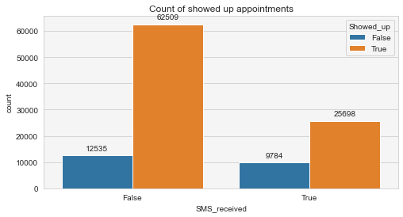

```python
plt.figure(figsize=(8,4))
ax = sns.countplot(x=df_q4["SMS_received"] , hue = df_q4["Showed_up"])

annotate_barplot(ax, '.0f')

ax.set_title("Count of showed up appointments");
```

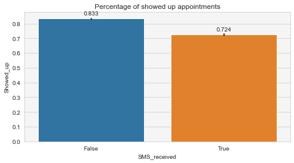

```python
plt.figure(figsize=(8,4))
ax = sns.barplot(x="SMS_received", y = "Showed_up", data = df_q4)

annotate_barplot(ax, '.3f')

ax.set_title("Percentage of showed up appointments");
```

**Items of Note:**

- Appointments for patients who receive an SMS message are 10.9% more likely to have the patient not show up.
- This is the largest discrepancy relative to the other features, as shown by the negative correlation from the correlation matrix (-0.13)
- In the given data, *SMS_received* could be a good indicator for a patient's likelihood to not show up to an appointment

## Conclusions

- For the purposes of predicting a patients likelihood to show up to an appointment:
- *Scholarship* & *SMS_received* showed negative correlation to likelihood to show up.
- *Age*, *Hipertension*, & *Diabetes* showed positive correlation to likelihood to show up.
- *Gender* & *Alchoholism* were bad indicators for the likelihood to show up.
- The analysis was limited by the following:
- More details are required to explain the unusual results with the *Scholarship* & *SMS_received* features. It would be expected that they both show a positive correlation.
- A more detailed analysis could be achieved if more features were provided, such as financial situation, distance from medical center, etc.
- The dataset's samples tend to skew heavily towards patients without any of the stated medical conditions and to those of young/middle age, making conclusions for these two features not as accurate.